# EDA Breast Cancer Proteomes: Dividing breast cancer patients into separate sub-classes

Wytze Bekker

9/21/2020

#### Introduction

This project is based on the publication Mertins, P., Mani, D., Ruggles, K. et al. Proteogenomics connects somatic mutations to signalling in breast cancer. Nature 534, 55-62 (2016). https://doi.org/10.1038/nature18003

From this publication, we can obtain 3 files:  
77_cancer_proteomes_CPTAC_itraq.csv, which contains log2 normalized expression values for several proteins from 80 breast cancer patients and 3 healthy individuals. The proteins are named with full names and symbols, but also with the RefSeq accession numbers so we can refer to the refseq database.

clinical_data_breast_cancer.csv, where we can find data about the cancer classification. It also contains information about several of the patiens also in 77_cancer_proteomes_CPTAC_itraq.csv, so we can combine these two datasets.

PAM50_proteins.csv contains the list of genes and proteins used by the PAM50 classification system. This one as well we can link to 77_cancer_proteomes_CPTAC_itraq.csv using the RefSeq accession numbers. We will not be using this file in this EDA, but might use it furtheron in the research.

The main target in this EDA is to remove some unuseful data and combine 77_cancer_proteomes_CPTAC_itraq.csv and clinicaldatabreast_cancer.csv to create one bigger dataset containing more data, which we can then use to answer our research question: Using machinelearning, can we predict/determine the subclass of breastcancer based on the patients protein expression values?

#### Codebooks

A description of most rows/columns in the datasets we use.  
Codebook for clinical_data_breast_cancer.csv:

| Number | Column | Description |
| --- | --- | --- |
| 1 | Complete TCGA ID | Matches the names in 77_cancer_proteomes_CPTAC_itraq.csv |
| 2 | Gender | Male/Female |
| 3 | Age at Initial Pathologic Diagnosis | Age in years |
| 4 | ER Status | Estrogen Receptor status (Positive or Negative) |
| 5 | PR Status | Progesterone Receptor status (Positive or Negative) |
| 6 | HER2 Final Status | HER2 protein status (Positive or Negative or Equivocal) |
| 7 | Tumor | Tumor classification (T1, T2, T3 or T4) |
| 8 | Tumor–T1 Coded | (T1 or T_Other) |
| 9 | Node | (N0, N1, N2 or N3) |
| 10 | Node-Coded | Has the cancer spread to nearby lymph nodes (Positive or Negative) |
| 11 | Metastasis | The development of secondary malignant growth at a distance from a primary site of cancer (M0 or M1) |
| 12 | Metastasis-Coded | Did metastasis occur (Positive or Negative) |
| 13 | AJCC Stage | Stage determined using TNM system from The American Joint Committee on Cancer |
| 14 | Converted Stage |  |
| 15 | Survival Data Form |  |
| 16 | Vital Status | The vital status of the patient (LIVING, DECEASED) |
| 17 | Days to Date of Last Contact | How many days since last contact with tumor (Number of days) |
| 18 | Days to date of Death | How many days from diagnosis to death (Number of days) |
| 19 | OS event | Overall Survival, has the patient survived? (0, 1) |
| 20 | OS Time | How many days from diagnosis to death (Number of days days) |
| 21 | PAM50 mRNA |  |
| 22 | SigClust Unsupervised mRNA |  |
| 23 | SigClust Intrinsic mRNA |  |
| 24 | miRNA Clusters |  |
| 25 | methylation Clusters |  |
| 26 | RPPA Clusters |  |
| 27 | CN Clusters |  |
| 28 | Integrated Clusters (with PAM50) |  |
| 29 | Integrated Clusters (no exp) |  |
| 30 | Integrated Clusters (unsup exp) |  |

Codebook for 77_cancer_proteomes_CPTAC_itraq.csv:

| Number | Column | Description |
| --- | --- | --- |
| 1 | RefSeqaccessionnumber | RefSeq protein ID, refers to the RefSeq database |
| 2 | gene_symbol | A symbol unique to each gene |
| 3 | gene_name | A full name of the gene |
| 4 | Remaining columns | Log2 iTRAQ protein expression ratios for each sample, three last columns are from healthy individuals |

#### Work

Open and read clinical_data_breast_cancer.csv: We show a little sample of the data: the first 7 columns and the PAM50 mRNA column because this is most likely the parameter we will predict towards when using machine learning.

```r
data_clin <- read.csv(file = "clinical_data_breast_cancer.csv")

kbl(head(data_clin[c(1:7, 21)])) %>%
  kable_styling()
```

| Complete.TCGA.ID | Gender | Age.at.Initial.Pathologic.Diagnosis | ER.Status | PR.Status | HER2.Final.Status | Tumor | PAM50.mRNA |
| --- | --- | --- | --- | --- | --- | --- | --- |
| TCGA-A2-A0T2 | FEMALE | 66 | Negative | Negative | Negative | T3 | Basal-like |
| TCGA-A2-A0CM | FEMALE | 40 | Negative | Negative | Negative | T2 | Basal-like |
| TCGA-BH-A18V | FEMALE | 48 | Negative | Negative | Negative | T2 | Basal-like |
| TCGA-BH-A18Q | FEMALE | 56 | Negative | Negative | Negative | T2 | Basal-like |
| TCGA-BH-A0E0 | FEMALE | 38 | Negative | Negative | Negative | T3 | Basal-like |
| TCGA-A7-A0CE | FEMALE | 57 | Negative | Negative | Negative | T2 | Basal-like |

Open and read 77_cancer_proteomes_CPTAC_itriaq.csv: We show a sample of the first 7 columns.

```r
data77 <- read.csv(file = "77_cancer_proteomes_CPTAC_itraq.csv", sep = ",", header = TRUE)
kbl(head(head(data77[1:7]))) %>%
  kable_styling()
```

| RefSeq_accession_number | gene_symbol | gene_name | AO.A12D.01TCGA | C8.A131.01TCGA | AO.A12B.01TCGA | BH.A18Q.02TCGA |
| --- | --- | --- | --- | --- | --- | --- |
| NP_958782 | PLEC | plectin isoform 1 | 1.096131 | 2.609943 | -0.6598280 | 0.1953407 |
| NP_958785 | NA | plectin isoform 1g | 1.111370 | 2.650422 | -0.6487422 | 0.2154129 |
| NP_958786 | PLEC | plectin isoform 1a | 1.111370 | 2.650422 | -0.6542851 | 0.2154129 |
| NP_000436 | NA | plectin isoform 1c | 1.107561 | 2.646374 | -0.6321133 | 0.2053768 |
| NP_958781 | NA | plectin isoform 1e | 1.115180 | 2.646374 | -0.6404277 | 0.2154129 |
| NP_958780 | PLEC | plectin isoform 1f | 1.107561 | 2.646374 | -0.6542851 | 0.2154129 |

We take a look at the dimensions before and after crudely omitting all NA’s

```
## [1] 12553    86
```

```
## [1] 6912   86
```

Omitting all NA’s removes roughly half of the data, this means there’s a lot of NA’s, but just simply removing all of them is too much, so we will try to still remove some but not so much. Working with this data will be easier if the table is transformed a bit.

We transpose the data so later on we can more easily combine it with the data from “clinical_data_breast_cancer.csv”, because both will have “the”Complete.TCGA.ID" as row names, which is the patient identifier code.

```r
##Take the RefSeq_accesstion_numbers so we can add those as columnnames
names <- data77$RefSeq_accession_number
##Transpose the data and readd the RefSeq_accession_number
data77.transp <- as.data.frame(t(data77[,4:86]))
colnames(data77.transp) <- names

##Add the Complete.TCGA.ID column
data77.transp <- cbind(rownames(data77.transp), data.frame(data77.transp, row.names = NULL))
colnames(data77.transp)[1] <- "Complete.TCGA.ID"
```

The values of Complete.TCGA.id refer to values in clinical_data_breast_cancer.csv, but are formatted differently, but we will now change them to be the same

```r
##Function to convert the TCGA id's to the correct format
get.clinical.id <- function(proteome.id) {
  x = substr(proteome.id, 4, 7)
  y = substr(proteome.id, 0, 2)
  paste("TCGA",y,x,sep="-")
}

##Use sapply to get the correctly formatted Complete.TCGA.ID column in data77.transp
data77.transp$Complete.TCGA.ID <- sapply(data77.transp$Complete.TCGA.ID, get.clinical.id)
```

We can now see how the NA’s are distributed. Most proteins have no NA’s so we will not include these in the plot.

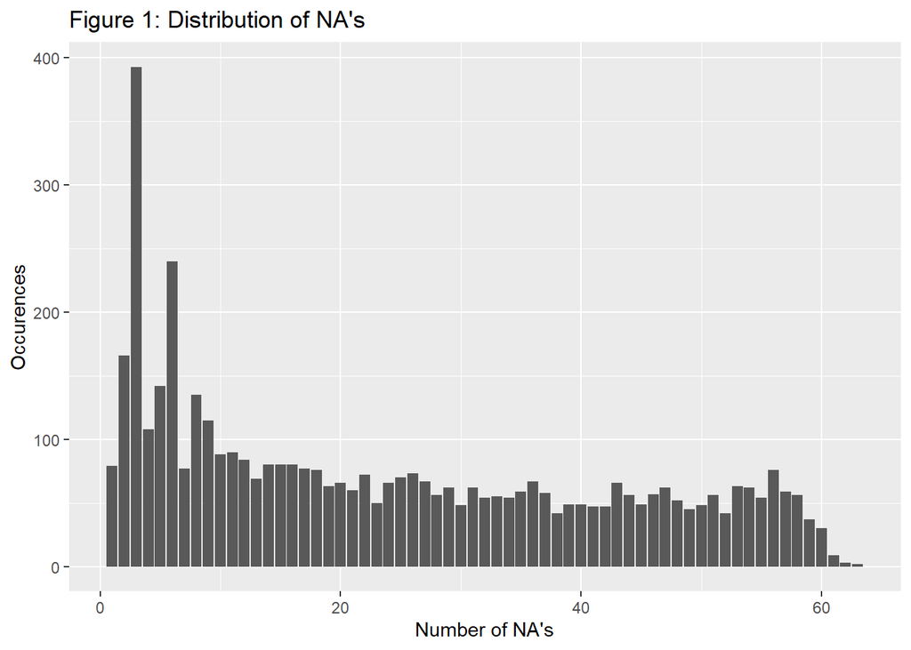

```r
##Count the amount of NA's per protein(column)
na_count <- sapply(data77.transp, function(y) sum(length(which(is.na(y)))))
na_count <- data.frame(na_count)

##Create a plot to show the distribution of NA's
na_count <- na_count[(na_count$na_count > 0),]
na_count <- data.frame(na_count)
ggplot(na_count, aes(na_count)) + geom_bar() +xlab("Number of NA's") + ylab("Occurences") +ggtitle("Figure 1: Distribution of NA's")
```

In figure 1 we can see there are a lot of proteins with 1-10 NA’s, but there is not a lot of difference in amounts of NA’s in the range 10-55. We will have to decide on a cutoff value for the amount of NA’s. This will be more than 20 NA’s, which, with a total of 80, equals 25%.

```r
##Remove proteins(columns) with more than 25%(=20) NA's
data77.filt <- data77.transp[,(colMeans(is.na(data77.transp))<0.25)]
```

We can see we have removed about 2200 proteins, which all contained too much NA’s.

Now we combine the modified data from “77_cancer_proteomes_CPTAC_itraq.csv” with the data from “clinical_data_breast_cancer.csv”.

```r
##Combine the two datasets
data.merged <- inner_join(data_clin, data77.filt, by = "Complete.TCGA.ID")
```

We now have one big table containing data from both 77_cancer_proteomes_CPTAC_itraq.csv and clinicaldatabreast_cancer.csv and removed several columns we deemed unusefull due to too many NA’s. We show a sample of some columns.

| Complete.TCGA.ID | Gender | Age.at.Initial.Pathologic.Diagnosis | ER.Status | NP_958781 | NP_958780 | NP_958783 |
| --- | --- | --- | --- | --- | --- | --- |
| TCGA-A2-A0CM | FEMALE | 40 | Negative | 0.6870771 | 0.6980976 | 0.6980976 |
| TCGA-BH-A18Q | FEMALE | 56 | Negative | 0.2154129 | 0.2154129 | 0.2154129 |
| TCGA-A7-A0CE | FEMALE | 57 | Negative | -1.1294857 | -1.1200168 | -1.1231731 |
| TCGA-D8-A142 | FEMALE | 74 | Negative | 0.5422105 | 0.5422105 | 0.5422105 |
| TCGA-AO-A0J6 | FEMALE | 61 | Negative | 0.8650092 | 0.8565398 | 0.8508936 |
| TCGA-A2-A0YM | FEMALE | 67 | Negative | 0.6512639 | 0.6581426 | 0.6558497 |

#### Usability

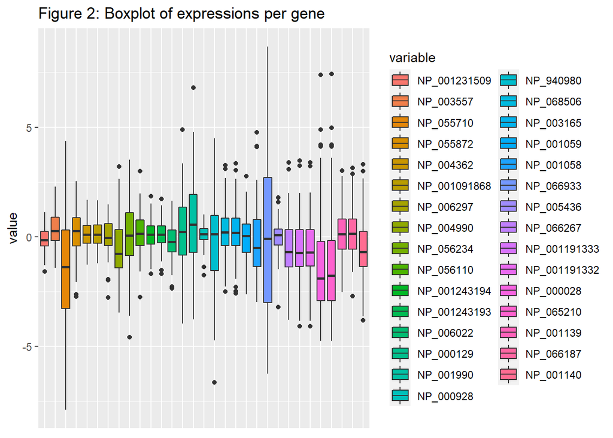

In figure 2 we can see that even with this big a dataset, there is still a lot of variety in the expression values. There are a lot of outliers, which might prove useful during machine learning.

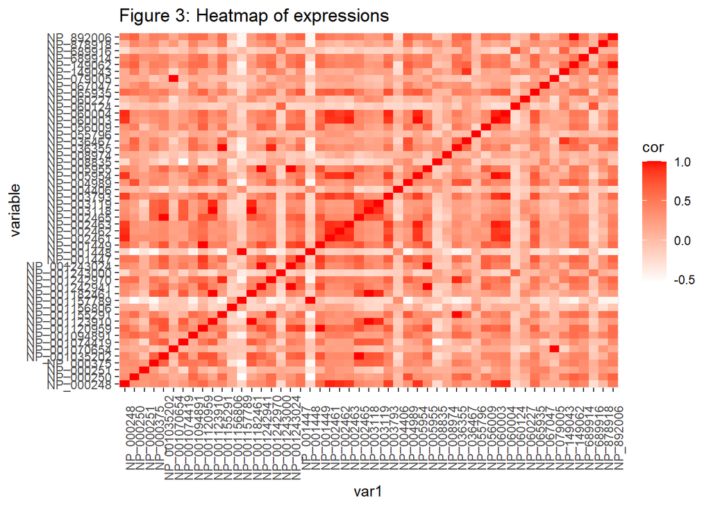

In figure 3 we can see several lighter lines, indicating that some genes have lower correlation with other genes. Considering this is a random selection, we can assume all of the data has similar levels/distribution in correlation. This means we can use these with machine learning to find patterns.

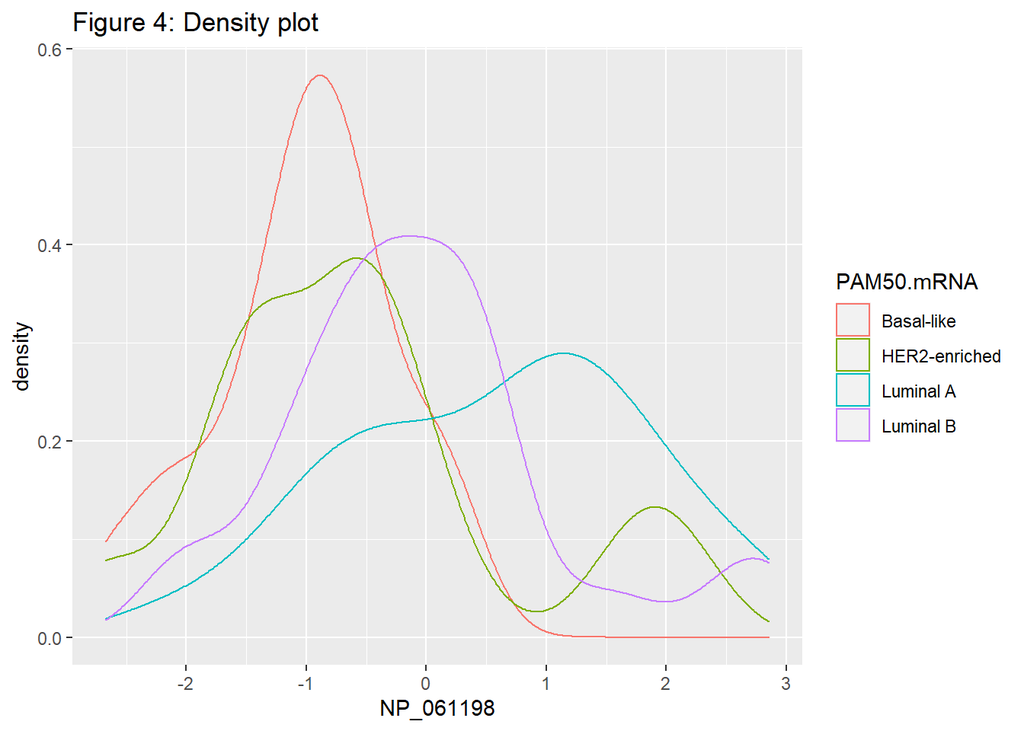

In figure 4 we can see for example that for the randomly chosen NP_061198 expression in Basal-like and HER2-enriched tumors is generally slightly below average.

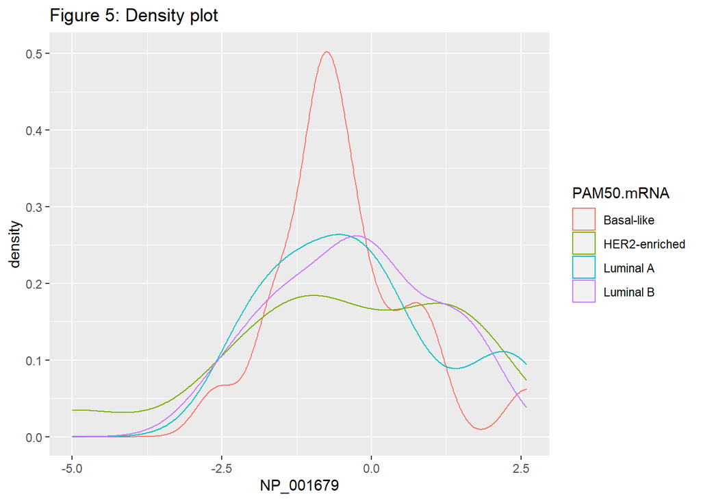

In figure 5 we can see a relatively big spike in Basal-like tumors, which could be a nice classifier for machine learning.

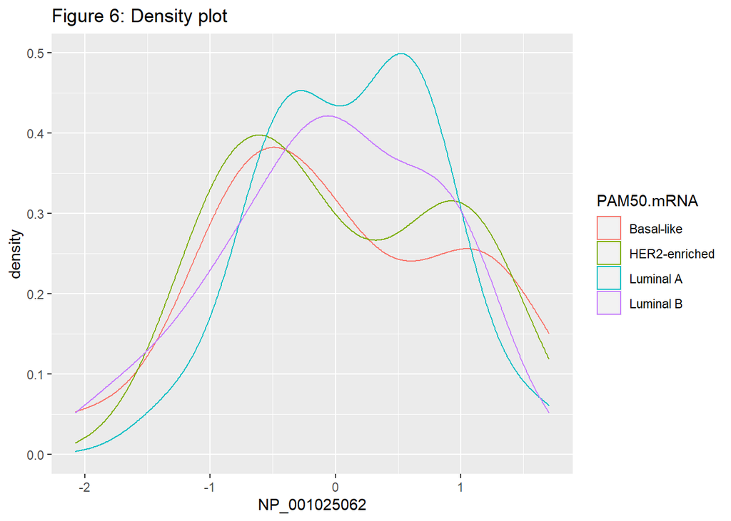

In figure 6 we can see that NP_001025062 is differently expressed in Luminal A tumors, yet again a possible handhold for machinelearning.

This data seems usable for subtyping via machine learning because even when randomly selecting a few attributes to compare, we can see clear differences in expression.

#### Conclusion

This data is usable for subtyping via machine learning because even when randomly selecting a few attributes to compare, we can see clear differences in expression. The data has been partially cleaned from NA’s, and combined into 1 dataset to use for machine learning.